# Homework 5

## Question 6

**Fit the models to your folded data using tune_grid(). Use autoplot() on the results.**

```r
tune_res <- tune_grid(
  multi_workflow,
  resamples = pokemon_fold,
  grid = reg_grid)
```

[output not shown]

[output not shown]

[output not shown]

[output not shown]

[output not shown]

[output not shown]

[output not shown]

[output not shown]

[output not shown]

[output not shown]

[output not shown]

[output not shown]

[output not shown]

[output not shown]

[output not shown]

[output not shown]

[output not shown]

[output not shown]

[output not shown]

[output not shown]

[output not shown]

[output not shown]

[output not shown]

[output not shown]

[output not shown]

[output not shown]

[output not shown]

[output not shown]

[output not shown]

[output not shown]

[output not shown]

[output not shown]

[output not shown]

[output not shown]

[output not shown]

[output not shown]

[output not shown]

[output not shown]

[output not shown]

[output not shown]

[output not shown]

[output not shown]

[output not shown]

[output not shown]

[output not shown]

[output not shown]

[output not shown]

[output not shown]

[output not shown]

[output not shown]

[output not shown]

[output not shown]

[output not shown]

[output not shown]

[output not shown]

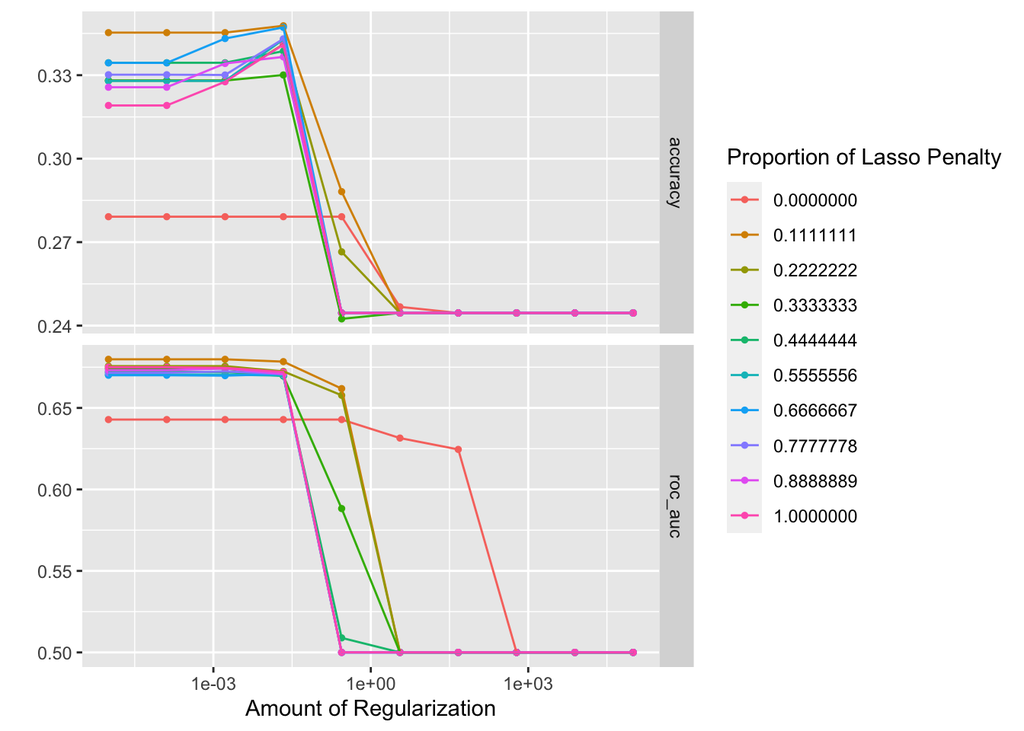

```r
autoplot(tune_res)
```

**What do you notice? Do larger or smaller values of penalty and mixture produce better accuracy and ROC AUC?**

## Question 7

**Use select_best() to choose the model that has the optimal roc_auc. Then use finalize_workflow(), fit(), and augment() to fit the model to the training set and evaluate its performance on the testing set.**

```r
best <- select_best(tune_res)
best
```

```
## # A tibble: 1 × 3
##   penalty mixture .config
##     <dbl>   <dbl> <chr>
## 1 0.00001   0.111 Preprocessor1_Model011
```

```r
final <- finalize_workflow(multi_workflow, best)
final_fit <- fit(final, data = pokemon_train)
aug <- augment(final_fit, new_data = pokemon_test)
aug
```

```
## # A tibble: 94 × 20
##    number name      type_1 type_2 total    hp attack defense sp_atk sp_def speed
##     <dbl> <chr>     <fct>  <chr>  <dbl> <dbl>  <dbl>   <dbl>  <dbl>  <dbl> <dbl>
##  1      3 Venusaur  Grass  Poison   525    80     82      83    100    100    80
##  2      4 Charmand… Fire   <NA>     309    39     52      43     60     50    65
##  3      6 Charizar… Fire   Flying   634    78    104      78    159    115   100
##  4      7 Squirtle  Water  <NA>     314    44     48      65     50     64    43
##  5      9 Blastoise Water  <NA>     530    79     83     100     85    105    78
##  6     12 Butterfr… Bug    Flying   395    60     45      50     90     80    70
##  7     15 Beedrill  Bug    Poison   395    65     90      40     45     80    75
##  8     15 Beedrill… Bug    Poison   495    65    150      40     15     80   145
##  9     18 Pidgeot   Normal Flying   479    83     80      75     70     70   101
## 10     18 PidgeotM… Normal Flying   579    83     80      80    135     80   121
## # … with 84 more rows, and 9 more variables: generation <dbl>, legendary <fct>,
## #   .pred_class <fct>, .pred_Bug <dbl>, .pred_Fire <dbl>, .pred_Grass <dbl>,
## #   .pred_Normal <dbl>, .pred_Psychic <dbl>, .pred_Water <dbl>
```

## Question 8

**Calculate the overall ROC AUC on the testing set.**

```r
aug %>% roc_auc(truth = type_1, estimate = c(.pred_Bug, .pred_Fire, .pred_Grass, .pred_Normal, .pred_Psychic, .pred_Water))
```

```
## # A tibble: 1 × 3
##   .metric .estimator .estimate
##   <chr>   <chr>          <dbl>
## 1 roc_auc hand_till      0.673
```

**Then create plots of the different ROC curves, one per level of the outcome. Also make a heat map of the confusion matrix.**

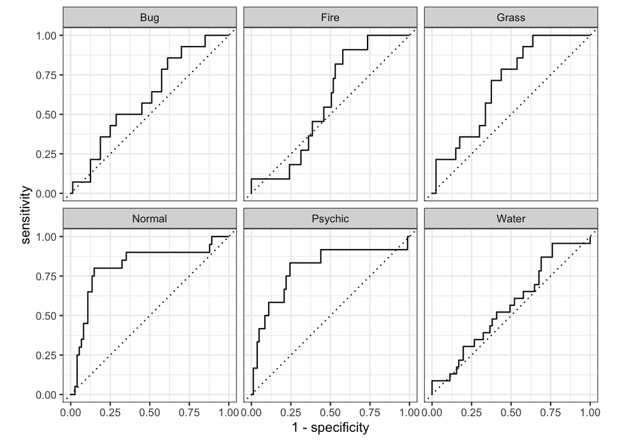

```r
aug %>% roc_curve(truth = type_1, estimate = c(.pred_Bug, .pred_Fire, .pred_Grass, .pred_Normal, .pred_Psychic, .pred_Water)) %>% autoplot()
```

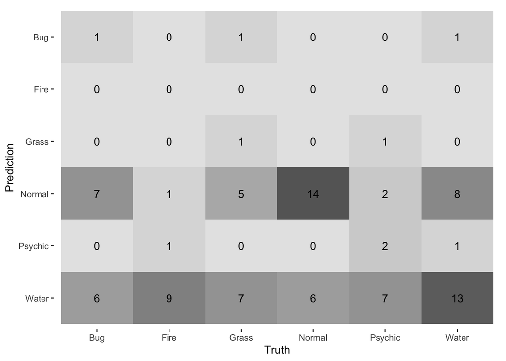

```r
aug %>% conf_mat(truth = type_1, estimate = .pred_class) %>% autoplot(type = "heatmap")
```

**What do you notice? How did your model do? Which Pokemon types is the model best at predicting, and which is it worst at? Do you have any ideas why this might be?**

With an AUC of 0.6732123, the model did decently well. Normal type and Water type predictions are the most accurate compared to the other types. Fire type had the worst predictions. This may be because of the low amount of pokemon of that type.